# SJP Eloff (10237161)

# Practical 4 - Data Wrangling

# Submission: 20 August 2018, 17:30

A researcher is interested in how variables, such as GRE (Graduate Record Exam scores), GPA (grade point average) and prestige of the undergraduate institution, effect admission into graduate school. The response variable, admit/don’t admit, is a binary variable

## Data Import

### Question 1 - Import the dataset ‘binary.csv’

1. Make sure your Working Directory is set to source file location
2. Save the data file in the same directory as this .rmd file

### Answers 1

```r
binary <- read.csv('binary.csv')
str(binary)
```

```
## 'data.frame':    400 obs. of  4 variables:
##  $ admit: int  0 1 1 1 0 1 1 0 1 0 ...
##  $ gre  : int  380 660 800 640 520 760 560 400 540 700 ...
##  $ gpa  : num  3.61 3.67 4 3.19 2.93 3 2.98 3.08 3.39 3.92 ...
##  $ rank : int  3 3 1 4 4 2 1 2 3 2 ...
```

### Question 2 - Tibbles

1. Print the first 20 values of the tibble ‘admit’
2. How many variables does the tibble have?
3. How many observations does the tibble have?
4. Extract the variable ‘gpa’ by name and assign it as the variable ‘gpa’
5. Extract the variable ‘gre’ by position and assign it as the variable ‘gre’

### Answers 2

```r
#a
admit <- fread('binary.csv',select=c(1),nrows=20)
admit
```

```
##     admit
##  1:     0
##  2:     1
##  3:     1
##  4:     1
##  5:     0
##  6:     1
##  7:     1
##  8:     0
##  9:     1
## 10:     0
## 11:     0
## 12:     0
## 13:     1
## 14:     0
## 15:     1
## 16:     0
## 17:     0
## 18:     0
## 19:     0
## 20:     1
```

2. The ‘admit’ tibble has 1 variable.
3. The ‘admit’ tibble has 20 observations.

```r
#d
gpa <- fread('binary.csv',select="gpa")
str(gpa)
```

```
## Classes 'data.table' and 'data.frame':   400 obs. of  1 variable:
##  $ gpa: num  3.61 3.67 4 3.19 2.93 3 2.98 3.08 3.39 3.92 ...
##  - attr(*, ".internal.selfref")=<externalptr>
```

```r
#e
gre <- fread('binary.csv',select=c(2))
str(gre)
```

```
## Classes 'data.table' and 'data.frame':   400 obs. of  1 variable:
##  $ gre: int  380 660 800 640 520 760 560 400 540 700 ...
##  - attr(*, ".internal.selfref")=<externalptr>
```

### Question 3 - Tidy data

The tidyr::who dataset contains tuberculosis (TB) cases broken down by year, country, age, gender, and diagnosis method. The data comes from the 2014 World Health Organization Global Tuberculosis Report. This is a very typical real-life example dataset. It contains redundant columns, odd variable codes, and many missing values. This case study is documented in the textbook ‘R for Data Science’.

```
## # A tibble: 7,240 x 60
##    country iso2  iso3   year new_sp_m014 new_sp_m1524 new_sp_m2534
##    <chr>   <chr> <chr> <int>       <int>        <int>        <int>
##  1 Afghan~ AF    AFG    1980          NA           NA           NA
##  2 Afghan~ AF    AFG    1981          NA           NA           NA
##  3 Afghan~ AF    AFG    1982          NA           NA           NA
##  4 Afghan~ AF    AFG    1983          NA           NA           NA
##  5 Afghan~ AF    AFG    1984          NA           NA           NA
##  6 Afghan~ AF    AFG    1985          NA           NA           NA
##  7 Afghan~ AF    AFG    1986          NA           NA           NA
##  8 Afghan~ AF    AFG    1987          NA           NA           NA
##  9 Afghan~ AF    AFG    1988          NA           NA           NA
## 10 Afghan~ AF    AFG    1989          NA           NA           NA
## # ... with 7,230 more rows, and 53 more variables: new_sp_m3544 <int>,
## #   new_sp_m4554 <int>, new_sp_m5564 <int>, new_sp_m65 <int>,
## #   new_sp_f014 <int>, new_sp_f1524 <int>, new_sp_f2534 <int>,
## #   new_sp_f3544 <int>, new_sp_f4554 <int>, new_sp_f5564 <int>,
## #   new_sp_f65 <int>, new_sn_m014 <int>, new_sn_m1524 <int>,
## #   new_sn_m2534 <int>, new_sn_m3544 <int>, new_sn_m4554 <int>,
## #   new_sn_m5564 <int>, new_sn_m65 <int>, new_sn_f014 <int>,
## #   new_sn_f1524 <int>, new_sn_f2534 <int>, new_sn_f3544 <int>,
## #   new_sn_f4554 <int>, new_sn_f5564 <int>, new_sn_f65 <int>,
## #   new_ep_m014 <int>, new_ep_m1524 <int>, new_ep_m2534 <int>,
## #   new_ep_m3544 <int>, new_ep_m4554 <int>, new_ep_m5564 <int>,
## #   new_ep_m65 <int>, new_ep_f014 <int>, new_ep_f1524 <int>,
## #   new_ep_f2534 <int>, new_ep_f3544 <int>, new_ep_f4554 <int>,
## #   new_ep_f5564 <int>, new_ep_f65 <int>, newrel_m014 <int>,
## #   newrel_m1524 <int>, newrel_m2534 <int>, newrel_m3544 <int>,
## #   newrel_m4554 <int>, newrel_m5564 <int>, newrel_m65 <int>,
## #   newrel_f014 <int>, newrel_f1524 <int>, newrel_f2534 <int>,
## #   newrel_f3544 <int>, newrel_f4554 <int>, newrel_f5564 <int>,
## #   newrel_f65 <int>
```

1. Tidy the tibble as illustrated in the textbook (http://r4ds.had.co.nz/tidy-data.html#case-study)
2. For each country, year, and sex compute the total number of cases of TB using grouping, filtering, sum and other functions.
3. Make an informative visualisation of the data in b (using three graphs)

```r
#a

who1 <- who %>%
  gather(key="key",value="cases",new_sp_m014:newrel_f65,na.rm=TRUE) %>%
  mutate(key=stringr::str_replace(key,"newrel","new_rel")) %>%
  separate(key, c("new","var","sexage")) %>%
  select(-new,-iso2,-iso3) %>%
  separate(sexage,c("sex","age"),sep=1)
#b
who2 <- who1 %>%
  group_by(country,year,sex) %>%
  filter(year>1995) %>%
  summarise(cases=sum(cases)) %>%
  unite(country_sex,country,sex,remove=FALSE) %>%
  unite(country_year,country,year,remove=FALSE)
who2
```

```
## # A tibble: 6,594 x 6
## # Groups:   country, year [3,320]
##    country_sex   country_year     country      year sex   cases
##    <chr>         <chr>            <chr>       <int> <chr> <int>
##  1 Afghanistan_f Afghanistan_1997 Afghanistan  1997 f       102
##  2 Afghanistan_m Afghanistan_1997 Afghanistan  1997 m        26
##  3 Afghanistan_f Afghanistan_1998 Afghanistan  1998 f      1207
##  4 Afghanistan_m Afghanistan_1998 Afghanistan  1998 m       571
##  5 Afghanistan_f Afghanistan_1999 Afghanistan  1999 f       517
##  6 Afghanistan_m Afghanistan_1999 Afghanistan  1999 m       228
##  7 Afghanistan_f Afghanistan_2000 Afghanistan  2000 f      1751
##  8 Afghanistan_m Afghanistan_2000 Afghanistan  2000 m       915
##  9 Afghanistan_f Afghanistan_2001 Afghanistan  2001 f      3062
## 10 Afghanistan_m Afghanistan_2001 Afghanistan  2001 m      1577
## # ... with 6,584 more rows
```

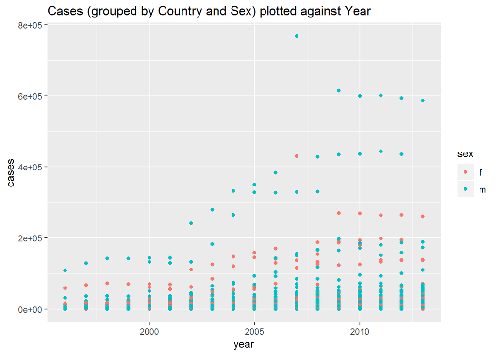

```r
#c
ggplot(who2,aes(x=year,y=cases,group=country_sex,colour=sex)) +
  geom_point() +
  ggtitle("Cases (grouped by Country and Sex) plotted against Year")
```

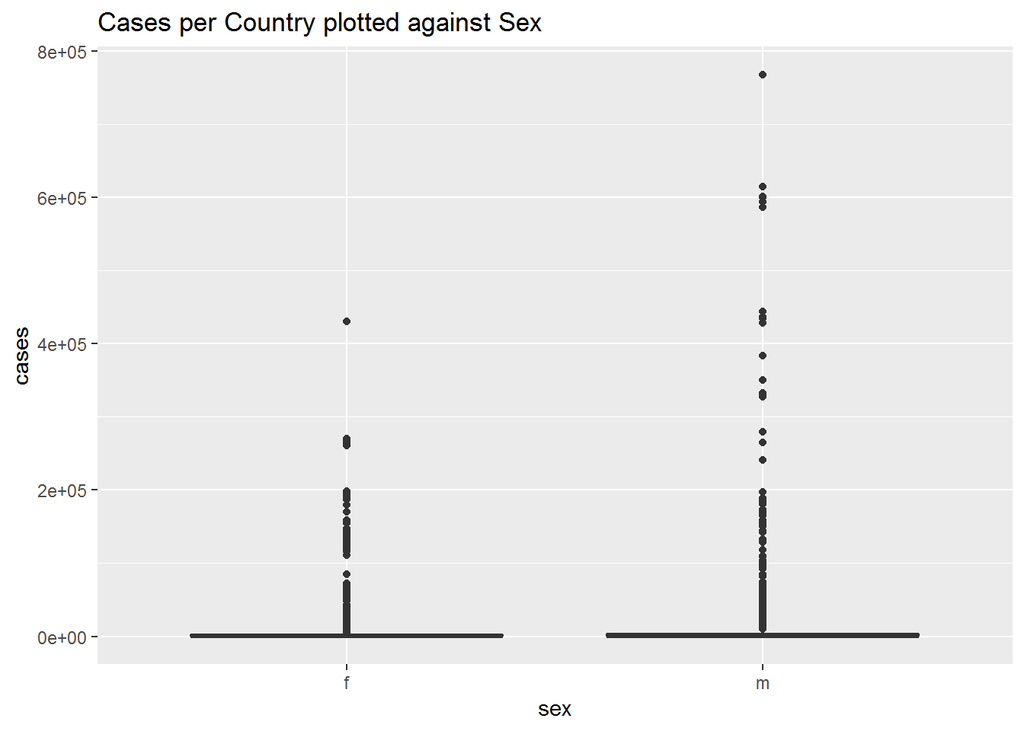

```r
ggplot(who2,aes(x=sex,y=cases,group=sex)) +
  geom_boxplot() +
  ggtitle("Cases per Country plotted against Sex")
```

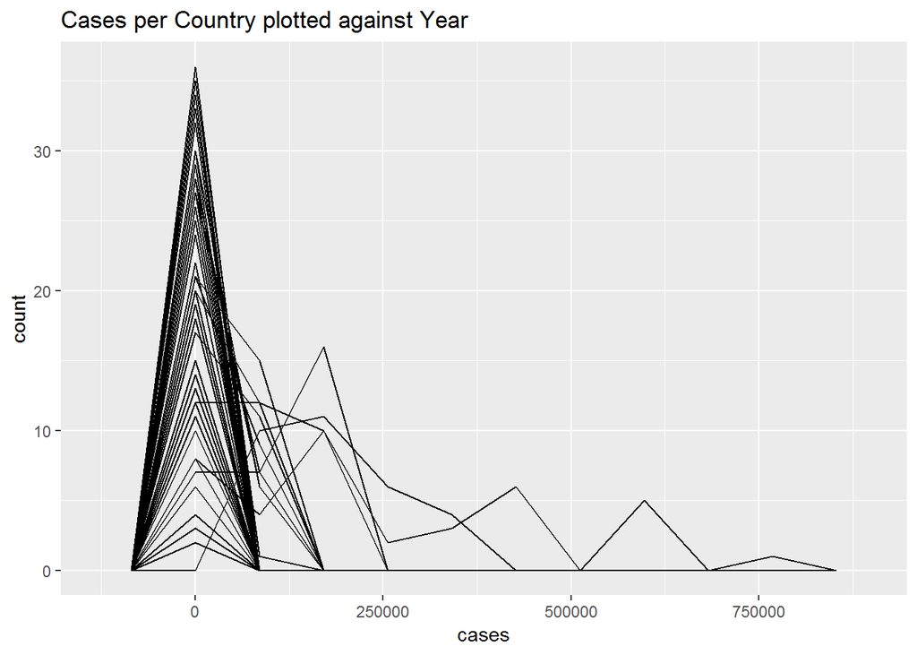

```r
ggplot(who2,aes(x=cases,stat=country)) +
  geom_freqpoly(bins=10) +
  ggtitle("Cases per Country plotted against Year")
```